# Admin-2 Prevalence Predictions: Dataset Description and Comparative Analysis

Individual-Level vs. Area-Level SuperLearner Predictions

Author

Micronutrient Prediction Project

Published

April 1, 2026

# 1 Overview

This document describes the Admin-2 (district-level) micronutrient deficiency prevalence prediction datasets produced by the proxy-only SuperLearner pipeline. These datasets are intended for external sharing and programmatic use.

**Two prediction approaches are compared:**

1. **Individual-level SL**: A SuperLearner ensemble trained on individual biomarker data with ~900-1,100 proxy predictors, then aggregated to Admin-2 by taking the survey-weighted mean of individual predictions.
2. **Area-level SL**: A SuperLearner trained directly on Admin-2 survey-weighted prevalence as the outcome, using GEE satellite raster zonal means as predictors. Two loss functions are tested:
   - **MSE (continuous)**: Standard squared-error loss with post-hoc clamping to [0,1]
   - **NLL (binomial)**: Negative log-likelihood / cross-entropy, which naturally handles bounded [0,1] prevalence (inspired by beta regression theory)

# 2 Data Sources

## 2.1 Survey data

| Country | Survey | Year | Children (n) | Women (n) | Clusters | Admin-2 units |
| --- | --- | --- | --- | --- | --- | --- |
| Gambia | GMS | 2018 | ~1,020 | ~1,413 | ~100 | ~40 |
| Ghana | DHS+ | 2017 | ~1,165 | ~1,005 | ~400 | ~216 |
| Sierra Leone | MNS | 2013 | ~486 | ~774 | ~60 | ~14 |
| Malawi | MNS | 2015-16 | ~1,100 | ~800 | ~87 | ~87 |

## 2.2 Predictor data (area-level models)

Area-level models use **GEE satellite raster zonal means** extracted for each Admin-2 polygon:

- NDVI, EVI (vegetation indices)
- Land surface temperature (day/night)
- FLDAS climate variables (soil moisture, temperature, precipitation)
- TRMM/GPM precipitation
- ESA WorldCereal crop classification
- SoilGrids soil properties (pH, carbon, nitrogen, iron, zinc, etc.)
- GHSL settlement classification
- CCNL nighttime lights
- GPW population demographics

Total: ~150-308 GEE variables per country after extraction.

# 3 Admin-2 Coverage

```r
coverage_rows <- list()
for (ctry in countries) {
  for (oc in outcomes) {
    svy <- load_target(paste0("svy_admin2_", ctry, "_", oc))
    if (is.null(svy) || nrow(svy) == 0) next
    coverage_rows[[paste0(ctry, "_", oc)]] <- data.frame(
      Country = country_labels[ctry],
      Outcome = outcome_labels[oc],
      `Surveyed Admin-2` = nrow(svy),
      `Mean n per Admin-2` = round(mean(svy$n_svy, na.rm = TRUE), 0),
      `Min n` = min(svy$n_svy, na.rm = TRUE),
      `Max n` = max(svy$n_svy, na.rm = TRUE),
      `Mean prev (%)` = round(mean(svy$svy_prev, na.rm = TRUE) * 100, 1),
      check.names = FALSE, stringsAsFactors = FALSE
    )
  }
}
if (length(coverage_rows) > 0) {
  cov_df <- bind_rows(coverage_rows)
  kable(cov_df, caption = "Admin-2 survey coverage by country and outcome") |>
    kable_styling(bootstrap_options = c("striped", "hover"),
                  full_width = FALSE, font_size = 11) |>
    collapse_rows(columns = 1, valign = "top")
}
```

Admin-2 survey coverage by country and outcome

|  | Country | Outcome | Surveyed Admin-2 | Mean n per Admin-2 | Min n | Max n | Mean prev (%) |
| --- | --- | --- | --- | --- | --- | --- | --- |
| gambia...1 | Gambia | Vitamin A (children) | 30 | 33 | 8 | 123 | 24.2 |
|  | Gambia | Vitamin A (women) | 30 | 47 | 11 | 231 | 4.0 |
|  | Gambia | Iron (children) | 30 | 33 | 8 | 123 | 42.5 |
|  | Gambia | Iron (women) | 30 | 46 | 11 | 224 | 35.9 |
| ghana...5 | Ghana | Vitamin A (children) | 75 | 16 | 1 | 47 | 18.7 |
|  | Ghana | Vitamin A (women) | 75 | 13 | 2 | 41 | 1.2 |
|  | Ghana | Iron (children) | 75 | 15 | 1 | 46 | 15.8 |
|  | Ghana | Iron (women) | 75 | 13 | 2 | 38 | 7.9 |
|  | Ghana | Folate (women) | 75 | 6 | 1 | 21 | 53.6 |
|  | Ghana | B12 (women) | 75 | 6 | 1 | 21 | 9.5 |
| sierraleone...11 | Sierra Leone | Vitamin A (children) | 14 | 35 | 14 | 54 | 17.9 |
|  | Sierra Leone | Vitamin A (women) | 14 | 55 | 23 | 108 | 1.6 |
|  | Sierra Leone | Iron (children) | 14 | 35 | 14 | 54 | 5.9 |
|  | Sierra Leone | Iron (women) | 14 | 55 | 23 | 108 | 9.0 |
|  | Sierra Leone | Folate (women) | 14 | 55 | 27 | 99 | 80.8 |
|  | Sierra Leone | B12 (women) | 14 | 55 | 27 | 101 | 0.4 |
| malawi...17 | Malawi | Vitamin A (children) | 87 | 13 | 1 | 43 | 20.0 |
|  | Malawi | Vitamin A (women) | 87 | 9 | 2 | 26 | 2.4 |
|  | Malawi | Iron (children) | 87 | 13 | 1 | 43 | 10.3 |
|  | Malawi | Iron (women) | 87 | 9 | 2 | 24 | 9.2 |
|  | Malawi | Folate (women) | 87 | 9 | 2 | 24 | 0.1 |
|  | Malawi | B12 (women) | 87 | 9 | 2 | 25 | 3.0 |
|  | Malawi | Zinc (children) | 87 | 12 | 1 | 43 | 58.1 |
|  | Malawi | Zinc (women) | 87 | 9 | 2 | 25 | 63.6 |

# 4 Comparative Analysis: Individual-Level vs. Area-Level SL

```r
area_comp <- load_target("area_comparison_all")
area_loco <- load_target("area_loco_comparison")
```

## 4.1 Within-Country Comparison

```r
if (!is.null(area_comp) && nrow(area_comp) > 0) {
  comp_display <- area_comp |>
    mutate(outcome_label = outcome_labels[outcome]) |>
    select(Country = country, Outcome = outcome_label, Approach = approach,
           `N Admin-2` = n_admin2, `MAE (pp)` = mae_pp, `RMSE (pp)` = rmse_pp,
           `Pearson r` = pearson_r, `Bias (pp)` = mean_bias_pp)

  kable(comp_display, caption = "Within-country Admin-2 prediction accuracy: three approaches compared") |>
    kable_styling(bootstrap_options = c("striped", "hover"),
                  full_width = FALSE, font_size = 10) |>
    collapse_rows(columns = 1:2, valign = "top")
} else {
  cat("Area comparison targets not yet available. Run the pipeline first.\n")
}
```

Within-country Admin-2 prediction accuracy: three approaches compared

| Country | Outcome | Approach | N Admin-2 | MAE (pp) | RMSE (pp) | Pearson r | Bias (pp) |
| --- | --- | --- | --- | --- | --- | --- | --- |
| Gambia | Vitamin A (children) | Individual SL | 30 | 4.24 | 5.79 | 0.914 | 0.66 |
|  |  | Area SL (MSE) | 30 | 3.75 | 4.90 | 0.963 | -0.13 |
|  |  | Area SL (NLL) | 30 | 4.04 | 5.44 | 0.935 | -2.35 |
|  | Vitamin A (women) | Individual SL | 30 | 1.43 | 1.85 | 0.970 | 0.06 |
|  |  | Area SL (MSE) | 30 | 0.16 | 0.21 | 1.000 | 0.01 |
|  |  | Area SL (NLL) | 30 | 2.07 | 3.78 | 0.923 | -1.79 |
|  | Iron (children) | Individual SL | 30 | 3.24 | 4.70 | 0.974 | 0.07 |
|  |  | Area SL (MSE) | 30 | 5.33 | 6.85 | 0.962 | 0.06 |
|  |  | Area SL (NLL) | 30 | 5.10 | 6.54 | 0.955 | -0.76 |
|  | Iron (women) | Individual SL | 30 | 4.74 | 6.89 | 0.921 | -0.18 |
|  |  | Area SL (MSE) | 30 | 7.19 | 9.39 | 0.812 | 0.00 |
|  |  | Area SL (NLL) | 30 | 7.03 | 9.22 | 0.818 | -0.83 |
| Ghana | Vitamin A (children) | Individual SL | 75 | 7.53 | 9.86 | 0.728 | 0.99 |
|  |  | Area SL (MSE) | 75 | 8.45 | 10.73 | 0.667 | 0.00 |
|  |  | Area SL (NLL) | 75 | 6.34 | 9.11 | 0.883 | -5.86 |
|  | Vitamin A (women) | Individual SL | 75 | 1.54 | 2.38 | 0.833 | 0.19 |
|  |  | Area SL (MSE) | 75 | 2.13 | 3.42 | 0.311 | 0.00 |
|  |  | Area SL (NLL) | 75 | 1.18 | 3.15 | 0.962 | -0.92 |
|  | Iron (children) | Individual SL | 75 | 4.40 | 6.72 | 0.930 | 0.42 |
|  |  | Area SL (MSE) | 75 | 8.61 | 12.06 | 0.744 | 0.03 |
|  |  | Area SL (NLL) | 75 | 9.54 | 14.92 | 0.724 | -7.71 |
|  | Iron (women) | Individual SL | 75 | 4.73 | 6.23 | 0.814 | 1.26 |
|  |  | Area SL (MSE) | 75 | 2.34 | 3.43 | 0.959 | 0.19 |
|  |  | Area SL (NLL) | 75 | 3.46 | 5.82 | 0.922 | -3.23 |
|  | Folate (women) | Individual SL | 75 | 11.69 | 14.89 | 0.903 | -0.25 |
|  |  | Area SL (MSE) | 75 | 9.35 | 11.18 | 0.967 | 0.01 |
|  |  | Area SL (NLL) | 75 | 7.72 | 10.55 | 0.934 | 1.62 |
|  | B12 (women) | Individual SL | 75 | 6.30 | 9.43 | 0.875 | -0.23 |
|  |  | Area SL (MSE) | 75 | 8.17 | 11.85 | 0.719 | 0.07 |
|  |  | Area SL (NLL) | 75 | 2.17 | 4.26 | 0.970 | -1.46 |
| Sierra Leone | Vitamin A (children) | Individual SL | 14 | 3.43 | 4.26 | 0.839 | 0.38 |
|  |  | Area SL (MSE) | 14 | 3.11 | 3.98 | 0.974 | -0.25 |
|  |  | Area SL (NLL) | 14 | 3.45 | 4.32 | 0.969 | -1.84 |
|  | Vitamin A (women) | Individual SL | 14 | 1.47 | 1.73 | 0.667 | 0.70 |
|  |  | Area SL (MSE) | 14 | 1.36 | 1.68 | NA | 0.00 |
|  |  | Area SL (NLL) | 14 | 0.79 | 1.28 | 0.864 | -0.59 |
|  | Iron (children) | Individual SL | 14 | 1.62 | 2.13 | 0.895 | 0.25 |
|  |  | Area SL (MSE) | 14 | 0.12 | 0.24 | 0.999 | 0.02 |
|  |  | Area SL (NLL) | 14 | 0.27 | 0.32 | 1.000 | -0.24 |
|  | Iron (women) | Individual SL | 14 | 1.70 | 2.05 | 0.964 | 0.18 |
|  |  | Area SL (MSE) | 14 | 2.25 | 3.03 | 0.987 | 0.07 |
|  |  | Area SL (NLL) | 14 | 3.62 | 5.39 | 0.715 | -2.09 |
|  | Folate (women) | Individual SL | 14 | 3.04 | 3.91 | 0.939 | -0.91 |
|  |  | Area SL (MSE) | 14 | 4.34 | 6.12 | 0.814 | 0.00 |
|  |  | Area SL (NLL) | 14 | 0.43 | 0.71 | 0.999 | 0.33 |
|  | B12 (women) | Individual SL | 14 | 0.64 | 0.69 | -0.312 | 0.10 |
|  |  | Area SL (MSE) | 14 | 0.60 | 0.68 | NA | 0.00 |
|  |  | Area SL (NLL) | 14 | 0.33 | 0.47 | 0.963 | -0.13 |
| Malawi | Vitamin A (children) | Individual SL | 87 | 7.20 | 9.42 | 0.735 | -0.07 |
|  |  | Area SL (MSE) | 87 | 4.35 | 5.51 | 0.971 | 0.31 |
|  |  | Area SL (NLL) | 87 | 8.91 | 12.49 | 0.492 | -4.78 |
|  | Vitamin A (women) | Individual SL | 87 | 2.45 | 3.81 | 0.847 | -0.03 |
|  |  | Area SL (MSE) | 87 | 3.72 | 5.24 | 0.440 | 0.00 |
|  |  | Area SL (NLL) | 87 | 2.50 | 5.77 | 0.643 | -2.10 |
|  | Iron (children) | Individual SL | 87 | 6.21 | 8.00 | 0.735 | -0.25 |
|  |  | Area SL (MSE) | 87 | 3.14 | 4.16 | 0.976 | -0.02 |
|  |  | Area SL (NLL) | 87 | 5.36 | 8.46 | 0.897 | -5.08 |
|  | Iron (women) | Individual SL | 87 | 4.63 | 6.07 | 0.897 | 0.27 |
|  |  | Area SL (MSE) | 87 | 4.03 | 5.90 | 0.957 | 0.31 |
|  |  | Area SL (NLL) | 87 | 5.51 | 10.16 | 0.922 | -5.21 |
|  | Folate (women) | Individual SL | 87 | 0.14 | 1.34 | NA | -0.14 |
|  | B12 (women) | Individual SL | 87 | 2.57 | 3.38 | 0.893 | 0.25 |
|  |  | Area SL (MSE) | 87 | 3.63 | 5.07 | 0.578 | 0.02 |
|  |  | Area SL (NLL) | 87 | 2.97 | 6.22 | 0.633 | -2.51 |
|  | Zinc (children) | Individual SL | 87 | 7.91 | 10.58 | 0.937 | 0.25 |
|  |  | Area SL (MSE) | 87 | 8.44 | 10.35 | 0.975 | -0.24 |
|  |  | Area SL (NLL) | 87 | 7.30 | 9.04 | 0.943 | 0.70 |
|  | Zinc (women) | Individual SL | 87 | 9.17 | 11.76 | 0.938 | -1.28 |
|  |  | Area SL (MSE) | 87 | 9.68 | 11.35 | 0.978 | -0.21 |
|  |  | Area SL (NLL) | 87 | 11.23 | 15.68 | 0.928 | 9.97 |

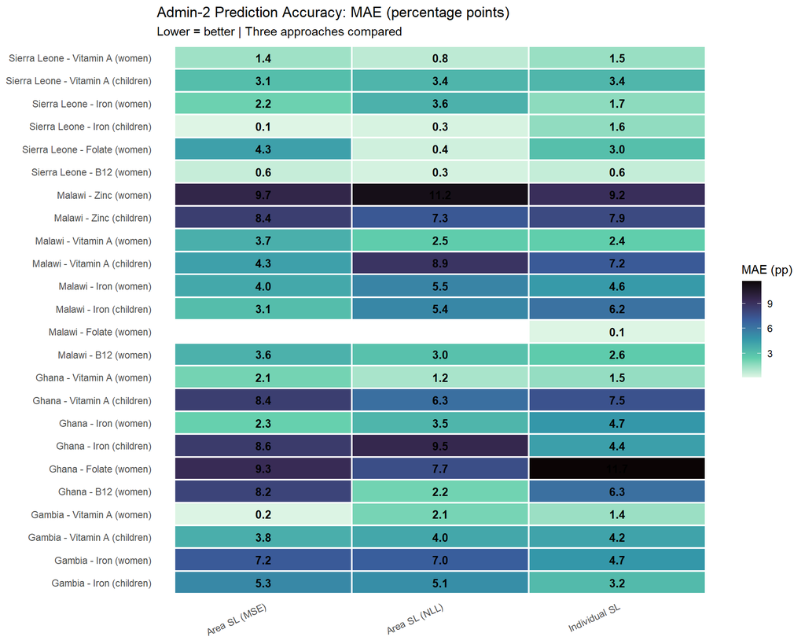

```r
if (!is.null(area_comp) && nrow(area_comp) > 0) {
  comp_plot <- area_comp |>
    mutate(
      outcome_label = outcome_labels[outcome],
      ctry_outcome = paste0(country, " - ", outcome_label)
    )

  ggplot(comp_plot, aes(x = approach, y = ctry_outcome, fill = mae_pp)) +
    geom_tile(colour = "white", linewidth = 0.8) +
    geom_text(aes(label = sprintf("%.1f", mae_pp)), size = 3.5, fontface = "bold") +
    scale_fill_viridis_c(name = "MAE (pp)", option = "mako", direction = -1) +
    labs(x = NULL, y = NULL,
         title = "Admin-2 Prediction Accuracy: MAE (percentage points)",
         subtitle = "Lower = better | Three approaches compared") +
    theme_minimal(base_size = 11) +
    theme(axis.text.x = element_text(angle = 25, hjust = 1),
          panel.grid = element_blank())
}
```

## 4.2 Cross-Country (LOCO) Area-Level Comparison

```r
if (!is.null(area_loco) && nrow(area_loco) > 0) {
  loco_display <- area_loco |>
    mutate(
      outcome_label = outcome_labels[outcome],
      loss = ifelse(model_type == "continuous", "MSE", "NLL")
    ) |>
    select(`Held out` = held_out, Outcome = outcome_label, Loss = loss,
           `N train` = n_train, `N test` = n_test,
           `Obs prev (%)` = obs_prev, `Pred prev (%)` = pred_prev,
           `MAE (pp)` = mae_pp, `Pearson r` = pearson_r) |>
    mutate(
      `Obs prev (%)` = round(`Obs prev (%)` * 100, 1),
      `Pred prev (%)` = round(`Pred prev (%)` * 100, 1)
    )

  kable(loco_display,
        caption = "Area-level LOCO: trained on 3 countries, tested on held-out country") |>
    kable_styling(bootstrap_options = c("striped", "hover"),
                  full_width = FALSE, font_size = 10) |>
    collapse_rows(columns = 1:2, valign = "top")
} else {
  cat("Area-level LOCO targets not yet available.\n")
}
```

Area-level LOCO: trained on 3 countries, tested on held-out country

| Held out | Outcome | Loss | N train | N test | Obs prev (%) | Pred prev (%) | MAE (pp) | Pearson r |
| --- | --- | --- | --- | --- | --- | --- | --- | --- |
| Gambia | Vitamin A (children) | MSE | 176 | 30 | 24.2 | 18.7 | 10.60 | 0.362 |
|  |  | NLL | 176 | 30 | 24.2 | 9.3 | 16.35 | 0.258 |
| Ghana |  | MSE | 131 | 75 | 18.7 | 19.9 | 11.03 | 0.447 |
|  |  | NLL | 131 | 75 | 18.7 | 21.4 | 12.78 | 0.015 |
| SierraLeone |  | MSE | 192 | 14 | 17.9 | 17.7 | 6.82 | -0.090 |
|  |  | NLL | 192 | 14 | 17.9 | 7.3 | 11.41 | -0.114 |
| Malawi |  | MSE | 119 | 87 | 20.0 | 28.9 | 13.49 | 0.203 |
|  |  | NLL | 119 | 87 | 20.0 | 31.7 | 17.05 | 0.159 |
| Gambia | Vitamin A (women) | MSE | 176 | 30 | 4.0 | 1.6 | 3.91 | -0.043 |
|  |  | NLL | 176 | 30 | 4.0 | 0.2 | 4.00 | 0.032 |
| Ghana |  | MSE | 131 | 75 | 1.2 | 2.7 | 3.23 | NA |
|  |  | NLL | 131 | 75 | 1.2 | 0.7 | 1.73 | 0.002 |
| SierraLeone |  | MSE | 192 | 14 | 1.6 | 2.2 | 1.49 | NA |
|  |  | NLL | 192 | 14 | 1.6 | 0.2 | 1.52 | 0.135 |
| Malawi |  | MSE | 119 | 87 | 2.4 | 3.6 | 4.70 | 0.073 |
|  |  | NLL | 119 | 87 | 2.4 | 0.6 | 2.78 | 0.052 |
| Gambia | Iron (children) | MSE | 176 | 30 | 42.5 | 16.0 | 27.06 | 0.175 |
|  |  | NLL | 176 | 30 | 42.5 | 5.8 | 36.79 | 0.148 |
| Ghana |  | MSE | 131 | 75 | 15.8 | 16.5 | 13.97 | 0.140 |
|  |  | NLL | 131 | 75 | 15.8 | 6.5 | 14.07 | -0.082 |
| SierraLeone |  | MSE | 192 | 14 | 5.9 | 13.8 | 8.10 | 0.029 |
|  |  | NLL | 192 | 14 | 5.9 | 3.6 | 4.83 | -0.103 |
| Malawi |  | MSE | 119 | 87 | 10.3 | 38.8 | 29.85 | -0.097 |
|  |  | NLL | 119 | 87 | 10.3 | 27.0 | 19.55 | -0.101 |
| Gambia | Iron (women) | MSE | 176 | 30 | 35.9 | 8.4 | 27.64 | -0.500 |
|  |  | NLL | 176 | 30 | 35.9 | 1.7 | 34.19 | -0.217 |
| Ghana |  | MSE | 131 | 75 | 7.9 | 16.2 | 10.98 | -0.003 |
|  |  | NLL | 131 | 75 | 7.9 | 8.2 | 7.42 | -0.023 |
| SierraLeone |  | MSE | 192 | 14 | 9.0 | 8.7 | 5.05 | -0.114 |
|  |  | NLL | 192 | 14 | 9.0 | 1.6 | 7.75 | -0.179 |
| Malawi |  | MSE | 119 | 87 | 9.2 | 20.9 | 15.62 | 0.001 |
|  |  | NLL | 119 | 87 | 9.2 | 13.0 | 10.65 | 0.055 |

# 5 Data Dictionary

The shared Admin-2 prediction CSV files contain the following columns:

| Column | Type | Description |
| --- | --- | --- |
| `Admin1` | character | Admin-1 (region/province) name |
| `Admin2` | character | Admin-2 (district) name |
| `country` | character | Country name |
| `outcome` | character | Outcome tag (e.g., child_vitA, women_iron) |
| `svy_prev` | numeric | Survey-weighted prevalence (0-1 scale) |
| `svy_prev_se` | numeric | Standard error of survey prevalence |
| `n_svy` | integer | Number of survey respondents in this Admin-2 |
| `sl_prev` | numeric | Individual-level SL predicted prevalence (aggregated) |
| `area_mse_prev` | numeric | Area-level SL predicted prevalence (MSE loss) |
| `area_nll_prev` | numeric | Area-level SL predicted prevalence (NLL/binomial loss) |
| `has_survey` | logical | Whether this Admin-2 has direct survey data |

**Note:** For Admin-2 units without survey data (`has_survey = FALSE`), `svy_prev` and `sl_prev` are `NA`. Area-level predictions (`area_mse_prev`, `area_nll_prev`) are available for all Admin-2 units with GEE raster coverage.

# 6 Quality Flags and Limitations

**Reliable predictions** (higher confidence):

- Admin-2 units with `n_svy >= 30` and `svy_prev_se < 0.05`
- Individual-level SL predictions for outcomes with within-country AUC > 0.70
- Area-level predictions where LOO MAE < 5 percentage points

**Uncertain predictions** (use with caution):

- Admin-2 units with `n_svy < 15` — survey estimates are unstable
- Predictions for outcomes with AUC near 0.50 (no individual-level discrimination)
- Area-level extrapolations to unsurveyed Admin-2 units (no direct validation possible)
- Sierra Leone predictions (fewer clusters, older survey)
- Malawi women_folate (continuous model only, 1 binary event)

**Caveats for external users:**

1. Predictions are cross-validated but not externally validated against independent surveys
2. Temporal extrapolation: surveys are from 2013-2018; predictions assume stable proxy-outcome relationships
3. Admin-2 boundaries follow GADM v4.1; name matching may differ from national definitions
4. Survey-weighted prevalences use design-based inference; SL predictions are model-based
5. The pipeline uses proxy-only predictors — no biomarker data from the same survey